# Capturing Heterogeneity in Gene Expression Studies by Surrogate Variable Analysis Jeffrey T Leek and John D Storey

March 12, 2015

## Gene Expression Studies

- Characterize transcriptional variablity
- Models fail to include unmodeled or unmeasured factors
- Noise can lead to a decrease power in detecting association

So, how do we handle background noise?

## Expression Heterogeneity (EH)

- Describes patterns of variation due to unmodeled factors
- Commonly expressed in human expression data and compelx systems
- Sources include technical, environmental, demographic, genetic factors, etc.

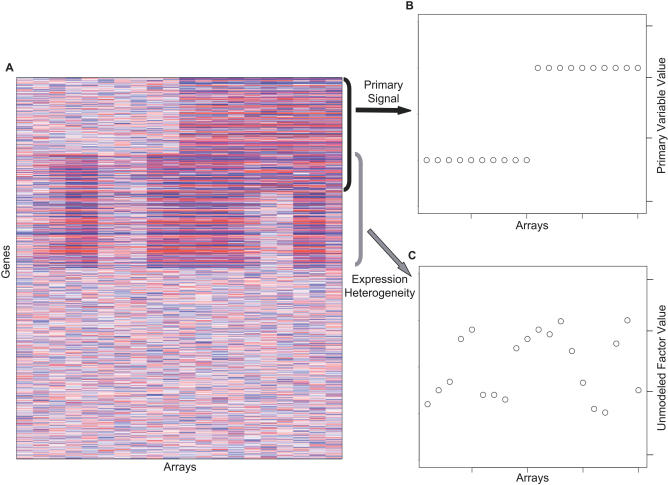

## Proposed Solution: Surrogate Variable Analysis (SVA)

- Identifies, estimates, and utilizes the components of EH
- Improves accuracy and consistency in detecting differential expression
- Captures signatures of EH and uses them as covariates in differential expression analysis

## Algoirthm Overview: Step 1

- Remove the signaldue to the primary variables to obtain a residual expression matrix
  - Form estimates \(\hat{\mu_i}\) and \(\hat{f_i}\) by fitting the model to \(x_{ij} = \mu_i + f_i(y_j) + e_{ij}^*\)
  - Caclulate residual expression matrix \(R\) where (i,j) element is \(r_{ij}\)

    \(r_{i,j} = x_{ij} - \hat{\mu_i} +\hat{f_i}(y_{j})\)
- Apply a decomposition to the residual expression matrix to identify signatures of EH (identifies signatures of the EH)
  - \(d_l\) is the lth orthagonal signatures of EH, "eigenvalue"
  - \(k\) is a gene corresponding to the signatures of EH, "eigengene"
  - Calculate a null statistic for each gene

  \[T_k = \dfrac{d_k^2}{\sum_{l=1}^{n-df} d_{0l}^2}\]
- Use a statistical test to determine the singular vectors that represent more variation than is expected by chance
  - calculate a p-value for the eigengene k

  \[p_k = \dfrac{\#{T_k^{0b} >= T_k; b = 1,...,B}}{B}\]

## Algorithm Overview: Step 2

- Identify subset of genes driving each signature
- Repeat step 1 including the signature eigenvalues

## Algorithm Overview: Step 3

- For each subset of genes, build a surrogate variable based on the full EH signature
- Build matrix containing all genes associated with the residual eigengene

## Algorithm Overview: Step 4

- Include all surrogate variables as covariates in subsequent regression analysis

\[x_{ij} = \mu_i + f_i(y_j) + \sum_{k=1}^K \gamma_{ki}\hat{h_{kj}} + e_{ij}\]

## Gene-Expression Profiles in Hereditary Breast Cancer

Hedenfalk I, Duggan D, Chen Y, et al. Gene-expression profiles in hereditary breast cancer. N Engl J Med. 2001 Feb 22;344(8):539-48.

## Background

- BRCA1 and BRCA2 contribute to many cases of hereditary breast cancer
- Mutation confers a lifetime risk of breast cancer of 50-85% and ovarian cancer of 15-45%
- BRCA1 and BRCA2 proteins participate in DNA repair and homologous recombination
- Tumors with BRCA1 and BRCA2 mutations have different pathological features

## BRCA1 vs. BRCA2

BRCA1

- High-grade cancers with high mitotic index
- "Pushing" tumor margins
- Lymphocytic infiltrate

BRCA2

- Heterogeneous
- Often relatively high-grade
- Display substantially less tubul formation

## Microarray

- Obtained samples of complementary DNA with verified sequences according to build 100 of UniGene human-sequence collection
- 6,512 cDNAs represent 5,361 unique genes
- 3,226 passed quality control criteria for average intensity levels and spot areas

## Statistical Analysis

- Differential gene expression analysis for BRCA1 or BRCA2 mutation
- Use LIMMA
- Use SVA to estimate latent batch effects
- Compare results with and without SVA

## Load Libraries

Load Libraries

## Read in BRCA data

```
## [1] TRUE
```

```
## [1] 3226   15
```

## Differential Expression by BRCA

```
## [1] 23
```

```
## [1] TRUE
```

## Run SVA

```
## [1] 1
```

```
## Number of significant surrogate variables is:  1
```

## Run LIMMA and include SV

```
## [1] 21
```

```
## [1] TRUE
```

## Visualize Data - Heat Map

```
## The "ward" method has been renamed to "ward.D"; note new "ward.D2"
```

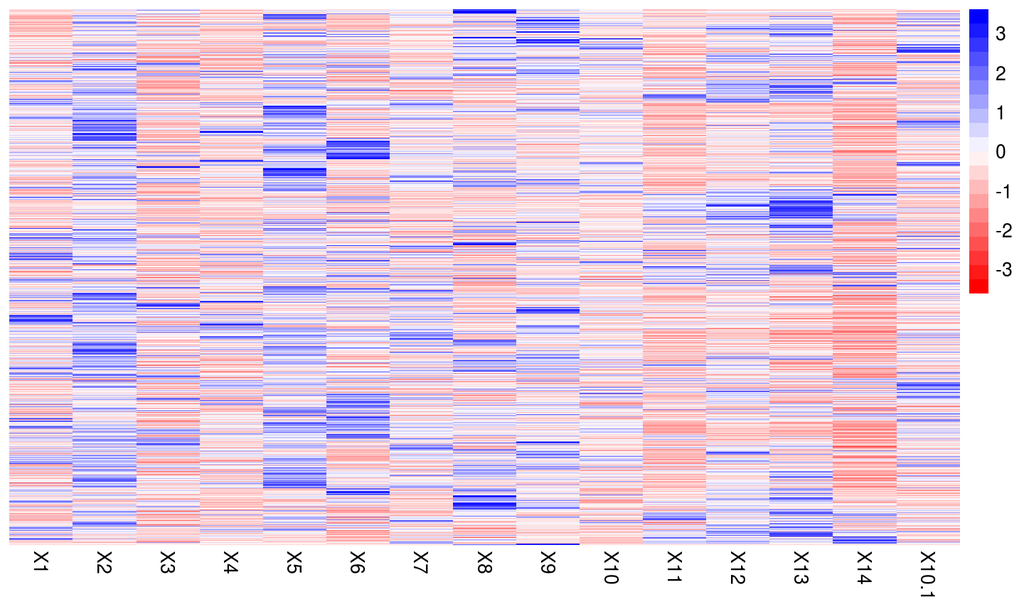

## Visualize Data - Plot of SV

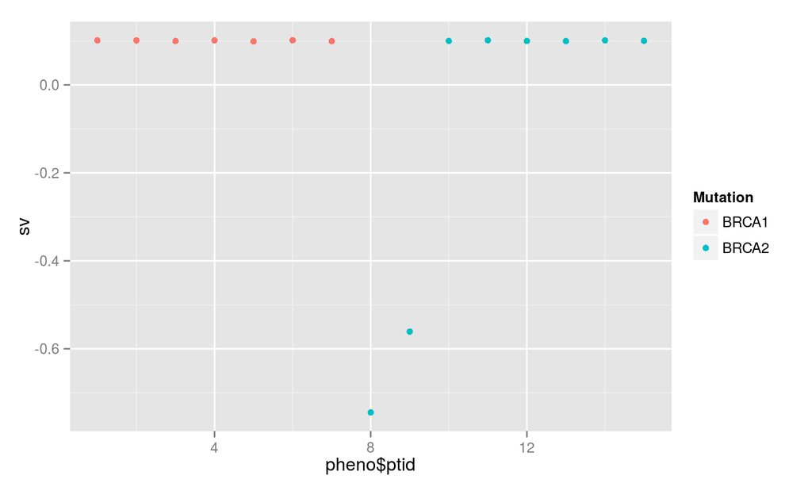

##Plot of EIF2S2

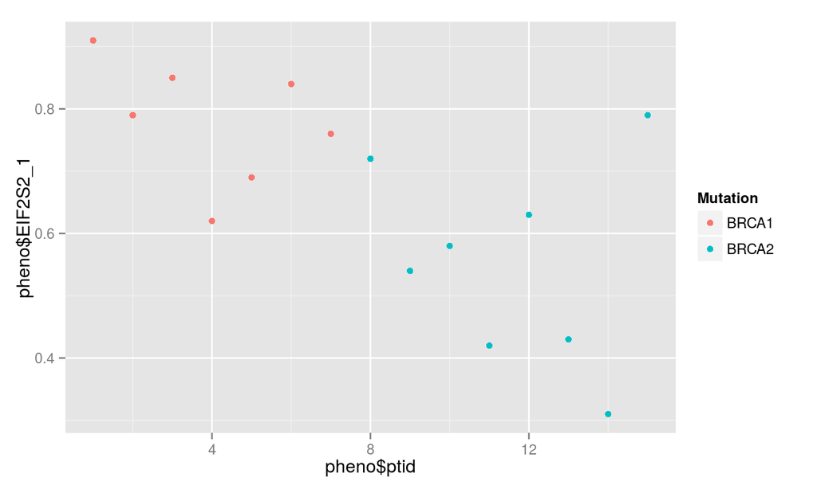

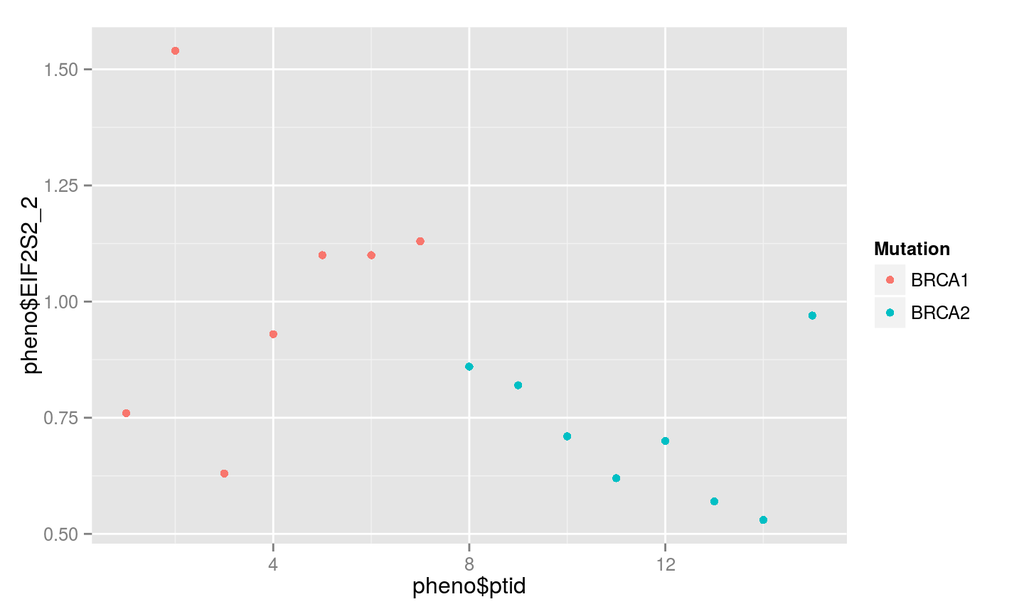

## Extra

Generality Model \(x_{ij} = \mu_{i} + f_{i}(y_{j} + e_{ij})\)

\(\gamma_{li}\) = gene-sepcific coefficient for the lth unmodeled factor

Expression for gene i on array j \(x_{ij} = \mu_{i} + f_{i}(y_{j} + \sum_{l=1}^L \gamma_{li}g_{li}+ e_{ij}^*)\)

Remove signal of primary variables creating a residual expression matrix

- Normalized expression matrix \(X_{mxn} = (x_{1},...,x_{m})^{T}\)
- Vector representing primary variable of interest \(y = (y_{1},...,y_{n})^{T}\)
- Baseline level of expression \(\mu\)

\[ \begin{aligned} x_{ij} = \mu_{i} + f_{i}(y_{j} + \sum_{l=1}^L \gamma_{li}g_{li}+ e_{ij}^*) \end{aligned} \] \[ \begin{aligned} x_{ij} = \mu_{i} + f_{i}(y_{j} + \sum_{k=1}^K \gamma_{ki}g_{ki}+ e_{ij}^*) \end{aligned} \]